# Car Data ML Project

date: “2023-06-12” —

### Introduction to Sports Car Data Analysis

Sports cars hold a significant place in modern culture, epitomizing speed, aesthetic appeal, and often serving as symbols of status and power. The diversity within the category of sports cars is vast, encompassing a range of designs from the visually stunning to the less aesthetically pleasing, varying speeds from the lightning-fast to the relatively sluggish, and different origins including European, Japanese, and American models. Given the variety found in the sports car segment, it presents an ideal subject for in-depth analysis through statistical methods.

[figure not shown]

### What is the Purpose of this analysis?

The objective of this project is to develop a predictive model that can ascertain the price of a sports car based on key attributes such as its speed, model year, and engine specifications. By inputting specific values into our model, we aim to estimate the market price of any given vehicle, including hypothetical models conceived for analytical purposes. This capability not only enhances our understanding of the factors influencing car valuations but also provides a versatile tool for forecasting the potential market value of future car designs.

### Loading Packages and Data

```r
#update.packages(ask = FALSE)
library(tidyverse)
library(dplyr)
library(tidymodels)
library(readr)
library(kknn)
library(janitor)
library(ISLR)
library(discrim)
library(poissonreg)
library(glmnet)
```

```r
library(corrr)
library(corrplot)
library(randomForest)
library(rpart.plot)
library(vip)
library(ranger)
library(ggplot2)

sportscar_data= read.csv('/Users/samarenson/Desktop/Sports car data/sportscarprice.csv')
tidymodels_prefer()
set.seed(500)

head(sportscar_data)
```

```
##      Car.Make Car.Model Year Engine.Size..L. Horsepower Torque..lb.ft.
## 1     Porsche       911 2022               3        379            331
## 2 Lamborghini   Huracan 2021             5.2        630            443
## 3     Ferrari   488 GTB 2022             3.9        661            561
## 4        Audi        R8 2022             5.2        562            406
## 5     McLaren      720S 2021               4        710            568
## 6         BMW        M8 2022             4.4        617            553
##   X0.60.MPH.Time..seconds. Price..in.USD.
## 1                        4        101,200
## 2                      2.8        274,390
## 3                        3        333,750
## 4                      3.2        142,700
## 5                      2.7        298,000
## 6                      3.1        130,000
```

This data is called “Sports Car Prices dataset” from kaggle, created by Kiattisak Rattanaporn.

## Exploring and Organizing the Data

### What does this dataset have to offer?

```r
dim(sportscar_data)
```

```
## [1] 1007    8
```

The dataset under examination comprises 1,007 observations, each representing a distinct vehicle, and includes eight variables. For the purposes of this analysis, the variable of interest, or response variable, is the car’s price. We will employ four predictor variables to forecast this price: engine size, horsepower, torque, and acceleration (0-60 mph time).

Engine Size: This variable represents the total volume of all the cylinders within the engine, typically measured in liters. In the context of this project, engine size is a crucial predictor as it often correlates with the vehicle’s power output and, by extension, its market value.

Horsepower: This is a measure of the engine’s power output. One horsepower equates to the power required to lift 550 pounds one foot off the ground in one second. In automotive contexts, higher horsepower is generally associated with higher performance levels, influencing the vehicle’s price.

Torque: Measured in foot-pounds (ft-lbs), torque reflects the rotational force the engine generates. Vehicles with higher torque can typically accelerate more forcefully from a standstill, impacting their desirability and price.

Acceleration (0-60 mph time): This measure indicates how quickly a vehicle can accelerate from a standstill to 60 miles per hour. It’s a critical performance indicator, with faster acceleration times often commanding higher prices in the sports car market.

Based on prior knowledge of automotive performance, it is hypothesized that there is a significant correlation among torque, 0-60 mph acceleration time, horsepower, and engine size. These interrelationships are anticipated due to the intrinsic mechanical and performance-related dependencies linking these variables.

[figure not shown]

### Converting factors

```r
colnames(sportscar_data) = c("Car Make", "Car Model", "Year", "EngineSize", "Horsepower", "Torque", "ZeroToSixty", "Price")
sportscar_data$Year= as.numeric((sportscar_data$Year))
sportscar_data$EngineSize= as.numeric((sportscar_data$EngineSize))
sportscar_data$Horsepower= as.numeric((sportscar_data$Horsepower))
sportscar_data$Torque= as.numeric((sportscar_data$Torque))
sportscar_data$ZeroToSixty= as.numeric((sportscar_data$ZeroToSixty))
sportscar_data$Price= (gsub(",", "", as.character(sportscar_data$Price)))
sportscar_data$Price= as.numeric((sportscar_data$Price))


head(sportscar_data)
```

```
##      Car Make Car Model Year EngineSize Horsepower Torque ZeroToSixty  Price
## 1     Porsche       911 2022        3.0        379    331         4.0 101200
## 2 Lamborghini   Huracan 2021        5.2        630    443         2.8 274390
## 3     Ferrari   488 GTB 2022        3.9        661    561         3.0 333750
## 4        Audi        R8 2022        5.2        562    406         3.2 142700
## 5     McLaren      720S 2021        4.0        710    568         2.7 298000
## 6         BMW        M8 2022        4.4        617    553         3.1 130000
```

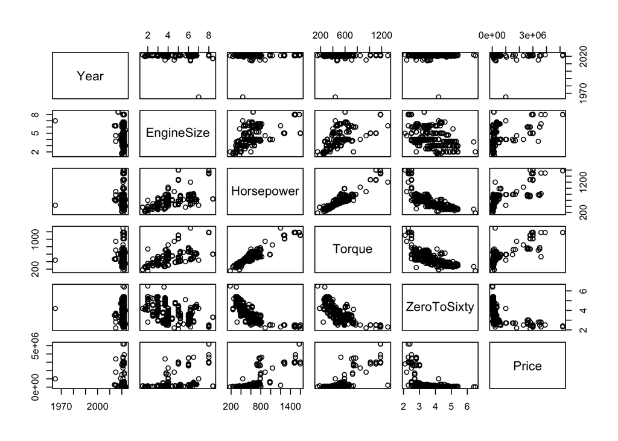

```r
dataset_without_make_model  <- subset(sportscar_data, select = -c(1:2))
dataset_without_make_model <- na.omit(dataset_without_make_model)
dataset_without_make_model$Price= as.numeric(dataset_without_make_model$Price)
plot(dataset_without_make_model)
```

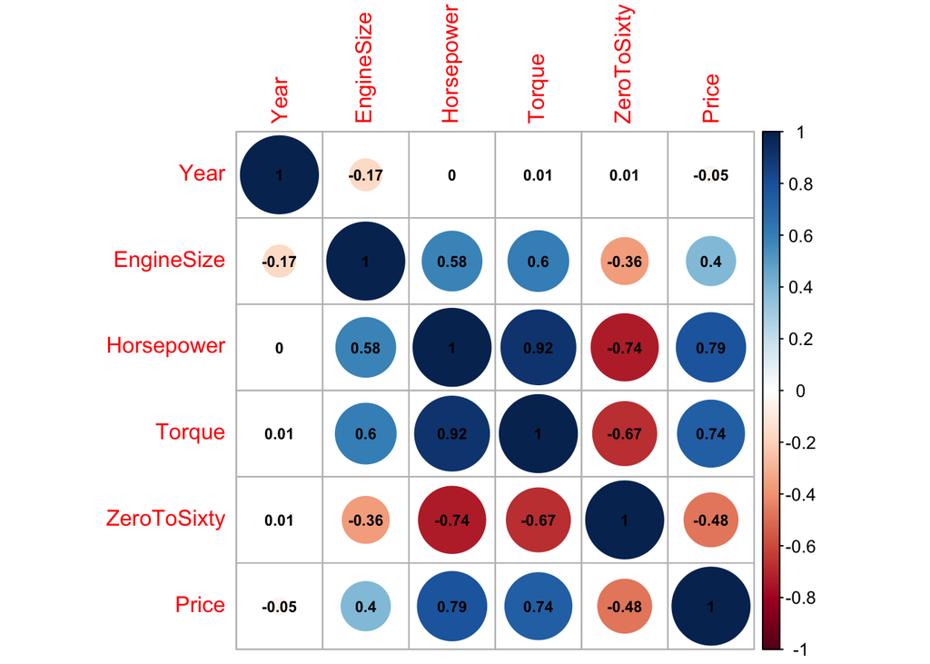

```r
# Assuming your dataset is called sportscar_datacopy


sportscar_cor <- cor(dataset_without_make_model)
if (any(is.na(sportscar_cor))) {
  # Handle missing values
  # For example, you can use imputation techniques or remove rows/columns with missing values
  sportscar_cor <- na.omit(sportscar_cor)
}
# Load the corrplot package (if not already loaded)
# install.packages("corrplot")  # Run this line if you haven't installed the corrplot package
library(corrplot)

sportcar_corrplot <- corrplot(sportscar_cor, method = "circle", addCoef.col = 1, number.cex = 0.7)
```

These plots show the relationships between the variables through different visual representations. The first plot graphically depicts the interactions among variables, while the correlation plot utilizes colored circles to signify the strength of correlations; with bluer circles indicating stronger positive correlations, and redder circles denoting stronger negative correlations.

It is logical to observe that Torque, Horsepower, and Engine Size are all positively correlated with each other, yet they exhibit negative correlations with the Zero to Sixty Time. This relationship might initially seem counterintuitive, but it becomes clearer upon reflection: higher values of Torque, Horsepower, and Engine Size typically lead to faster cars, reflected by lower Zero to Sixty Times—a desirable attribute in performance vehicles.

Let us now delve further into the specifics of these variables.Year

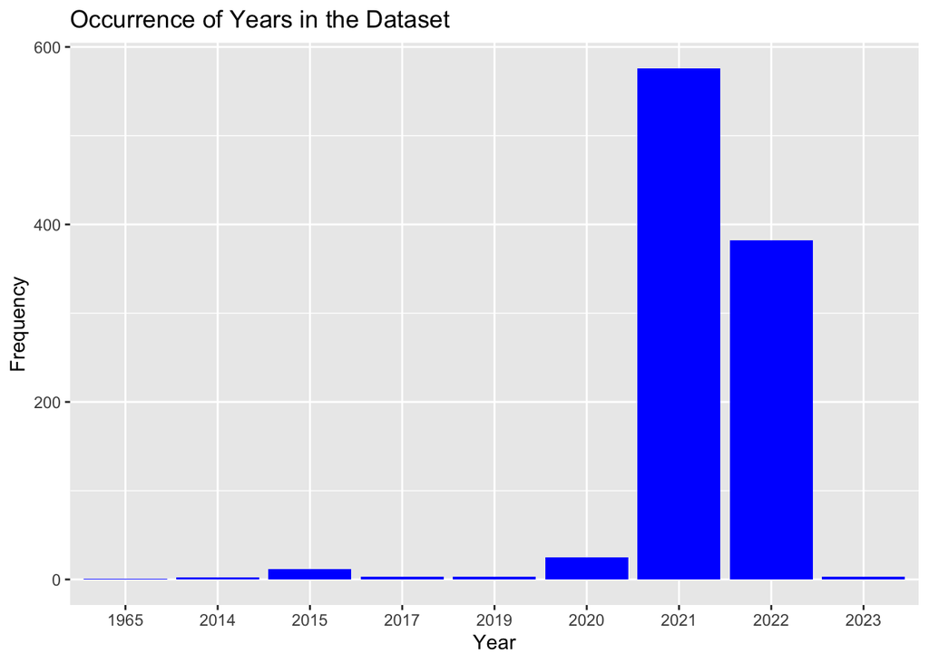

```r
year = sportscar_data$Year
# Assuming your dataset is called sports_car_data and "year" is the variable name
ggplot(sportscar_data, aes(x = as.factor(year))) +
  geom_bar(fill = "blue") +
  labs(x = "Year", y = "Frequency") +
  ggtitle("Occurrence of Years in the Dataset")
```

The dataset predominantly consists of vehicles from the years 2021 and 2022. Ideally, a dataset with a uniform distribution of model years would provide a more comprehensive overview. Nevertheless, this dataset’s composition is also useful, despite an overrepresentation of 2021 models. Incorporating a wider range of model years could allow for the inclusion of ‘Year’ as a predictive factor for car prices, although this would require adjustments for cumulative inflation and other historical context. Such an analysis would offer valuable insights into the changes in car pricing over time.

### Engine Size

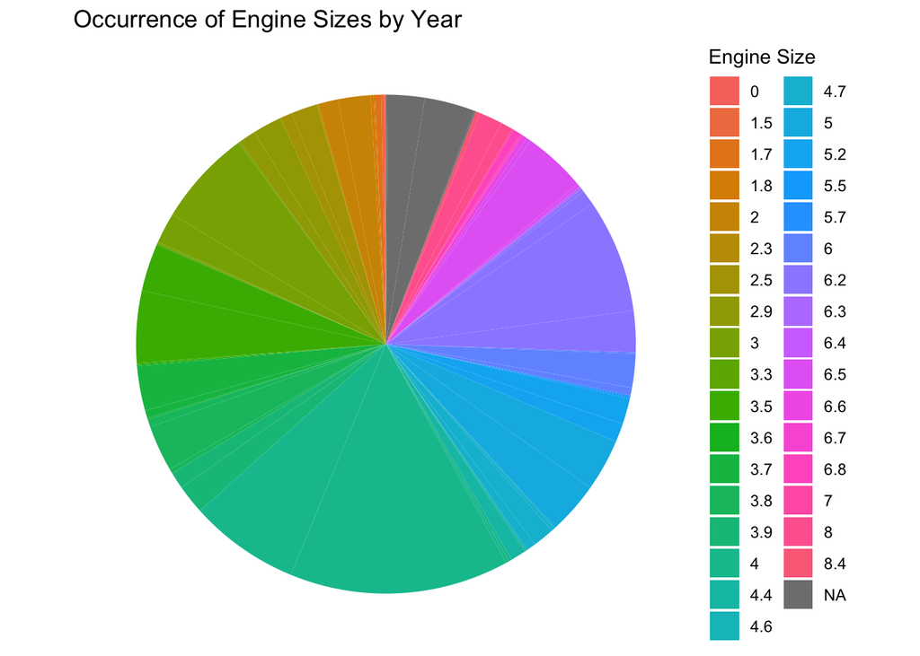

```r
enginesize= sportscar_data$Engine.Size..L.
# Assuming your dataset is called sports_car_data and contains variables "year" and "engine_size"
library(dplyr)  # Load the dplyr package

# Count the frequency of each combination of year and engine size
engine_size_counts <- sportscar_data %>%
  count(Year, EngineSize)

# Pie chart
ggplot(engine_size_counts, aes(x = "", y = n, fill = factor(EngineSize))) +
  geom_bar(stat = "identity", width = 1) +
  coord_polar("y", start = 0) +
  labs(fill = "Engine Size", x = NULL, y = NULL) +
  ggtitle("Occurrence of Engine Sizes by Year") +
  theme_void()  # Remove unnecessary elements
```

As we can see here, most of the engine sizes are between 3.3 and 5 liters.

### Horsepower and Torque

```r
hp= as.numeric(sportscar_data$Horsepower)
torque = as.numeric(sportscar_data$Torque)
summary(hp)
```

```
##    Min. 1st Qu.  Median    Mean 3rd Qu.    Max.    NA's
##   181.0   454.0   591.0   627.3   671.0  2000.0       9
```

```r
summary(torque)
```

```
##    Min. 1st Qu.  Median    Mean 3rd Qu.    Max.    NA's
##     0.0   406.0   509.0   542.2   604.0  1732.0       8
```

As we can see, the averages for HP and torque are 627.3 and 542.2 respectively. There are incredible performance numbers. This tells us that this data set is biased towards high performance vehicles like super cars and hyper cars, and excludes many low end (budget) sports cars.

### Price (the response)

```r
sportscar_data$Price= as.numeric(sportscar_data$Price)
summary(sportscar_data$Price)
```

```
##    Min. 1st Qu.  Median    Mean 3rd Qu.    Max.
##   25000   71800  140000  382036  250000 5200000
```

```r
sd(sportscar_data$Price)
```

```
## [1] 738322.7
```

### Missing data

Missing data can skew our results, so we need to see how the missing data is distributed throughout the dataset.

```r
sportscar_data %>%
  summary()
```

```
##    Car Make          Car Model              Year        EngineSize
##  Length:1007        Length:1007        Min.   :1965   Min.   :0.000
##  Class :character   Class :character   1st Qu.:2021   1st Qu.:3.500
##  Mode  :character   Mode  :character   Median :2021   Median :4.000
##                                        Mean   :2021   Mean   :4.396
##                                        3rd Qu.:2022   3rd Qu.:5.200
##                                        Max.   :2023   Max.   :8.400
##                                                       NA's   :59
##    Horsepower         Torque        ZeroToSixty        Price
##  Min.   : 181.0   Min.   :   0.0   Min.   :1.800   Min.   :  25000
##  1st Qu.: 454.0   1st Qu.: 406.0   1st Qu.:2.900   1st Qu.:  71800
##  Median : 591.0   Median : 509.0   Median :3.500   Median : 140000
##  Mean   : 627.3   Mean   : 542.2   Mean   :3.515   Mean   : 382036
##  3rd Qu.: 671.0   3rd Qu.: 604.0   3rd Qu.:4.000   3rd Qu.: 250000
##  Max.   :2000.0   Max.   :1732.0   Max.   :6.500   Max.   :5200000
##  NA's   :9        NA's   :8        NA's   :1
```

The dataset shows that ‘Year’ has no missing entries, while ‘Engine Size’ has 59 missing values, ‘Horsepower’ has 9, ‘Torque’ has 8, and ‘0-60 Time’ has only 1. The missing values in all variables except for ‘Engine Size’ appear to be random data entry errors. In contrast, the missing ‘Engine Size’ data specifically relates to electric vehicles, as indicated by their designation as “electric” prior to data tidying. Since electric motors are not measured in liters, these entries were converted to NA during the numeric conversion of this variable, making it necessary to remove them.

Furthermore, given that horsepower and torque measurements for electric vehicles differ significantly from those for gasoline-powered cars, it is essential to exclude the entire observation for each vehicle missing the ‘Engine Size’ data to maintain data integrity. This approach ensures that the remaining data, free from these specific inconsistencies, contributes effectively to building a robust model.

```r
sportscar_data <- sportscar_data[complete.cases(sportscar_data$EngineSize), ]
sportscar_data <- sportscar_data[!(sportscar_data$'Car Make' == "Tesla" & sportscar_data$'Car Model' == "Roadster"), ]
sportscar_data[sportscar_data$'Car Make' == "Bugatti" & sportscar_data$"Car Model" == "Chiron", c("Horsepower", "Torque")] <- c(1500, 1180)



sportscar_data %>%
  summary()
```

```
##    Car Make          Car Model              Year        EngineSize
##  Length:947         Length:947         Min.   :1965   Min.   :1.5
##  Class :character   Class :character   1st Qu.:2021   1st Qu.:3.5
##  Mode  :character   Mode  :character   Median :2021   Median :4.0
##                                        Mean   :2021   Mean   :4.4
##                                        3rd Qu.:2022   3rd Qu.:5.2
##                                        Max.   :2023   Max.   :8.4
##    Horsepower         Torque        ZeroToSixty        Price
##  Min.   : 181.0   Min.   : 151.0   Min.   :2.100   Min.   :  25000
##  1st Qu.: 454.0   1st Qu.: 398.0   1st Qu.:3.000   1st Qu.:  70348
##  Median : 583.0   Median : 505.0   Median :3.500   Median : 120000
##  Mean   : 590.1   Mean   : 515.8   Mean   :3.589   Mean   : 342920
##  3rd Qu.: 660.0   3rd Qu.: 590.0   3rd Qu.:4.000   3rd Qu.: 240500
##  Max.   :1600.0   Max.   :1500.0   Max.   :6.500   Max.   :5200000
```

I excluded the electric cars from the dataset, resulting in the removal of most entries listed as NA for ‘Engine Size’. Consequently, the overall metrics of the dataset remained largely unchanged. Additionally, most of the other NA values were eliminated during this process. I also identified and rectified two other observations that had missing values. By researching their specifications online, I was able to manually update the dataset with the correct information.

## Creating Models

Now we must create our models. To do this, we’re going to split our data up, create our model recipes, and cross validate.

### Splitting Data

The fundamental goal of developing our models is to accurately predict outcomes for new data inputs. To achieve this, we must divide our data into training and testing subsets. The training set trains the models, while the testing set evaluates their performance on unseen data, with the ideal model demonstrating minimal error on the testing set. While a common practice is to use a 70/30 split between training and testing data, we have opted for a 65/35 split. This adjustment allows us to ensure a more thorough representation of data in the testing phase, which is viable given the substantial size of our dataset. Additionally, we will stratify the data by the ‘0-60 time’ to maintain a balanced representation of fast and slow cars in both sets.

```r
# Ensure the sportscar_data is available
# sportscar_data <- your_existing_dataframe

# Adding a new column ZeroToSixty_factor by converting ZeroToSixty to a factor
sportscar_data$ZeroToSixty_factor <- as.factor(sportscar_data$ZeroToSixty)
head(sportscar_data,50)
```

```
##         Car Make              Car Model Year EngineSize Horsepower Torque
## 1        Porsche                    911 2022        3.0        379    331
## 2    Lamborghini                Huracan 2021        5.2        630    443
## 3        Ferrari                488 GTB 2022        3.9        661    561
## 4           Audi                     R8 2022        5.2        562    406
## 5        McLaren                   720S 2021        4.0        710    568
## 6            BMW                     M8 2022        4.4        617    553
## 7  Mercedes-Benz                 AMG GT 2021        4.0        523    494
## 8      Chevrolet               Corvette 2021        6.2        490    465
## 9           Ford   Mustang Shelby GT500 2022        5.2        760    625
## 10        Nissan             GT-R Nismo 2021        3.8        600    481
## 11  Aston Martin                   DB11 2021        5.2        630    516
## 12       Bugatti                 Chiron 2021        8.0       1500   1500
## 13         Dodge Challenger SRT Hellcat 2022        6.2        717    656
## 14        Jaguar                 F-Type 2022        3.0        296    295
```

[output cut: 87 more lines]

```r
# Now sportscar_data will have an additional column named ZeroToSixty_factor
```

```r
set.seed(500)


sportscar_split = initial_split(sportscar_data, prop=.65, strata= ZeroToSixty_factor)

sportscar_train = training(sportscar_split)
sportscar_test = testing(sportscar_split)

nrow(sportscar_train)/nrow(sportscar_data)
```

```
## [1] 0.6494192
```

We’ve split the data up properly.

[figure not shown]

### Recipe Creation

This recipe based on our data will serve to create all of our models. For our predictors, we will use 0-60 time (in seconds), horsepower (in hp), torque (in lb-ft), and engine size (in liters) to predict car price.

```r
sportscar_recipe = recipe(Price ~ EngineSize + Horsepower + Torque + ZeroToSixty , data= sportscar_data) %>%
    step_center(all_predictors()) %>%
    step_scale(all_predictors())




#sportscar_recipe = recipe(Price..in.USD ~ Horsepower + Torque..lb..ft)
```

### K fold Cross Validation

```r
sportscar_folds = vfold_cv(sportscar_train, v = 10, strata = ZeroToSixty)
```

K-fold cross-validation is a technique used to assess the performance of a model by estimating its accuracy on unseen data. It addresses the issue of overfitting and provides a more reliable estimate of the model’s generalization ability.

In k-fold cross-validation, the dataset is divided into k ( in our case 10) approximately equal-sized folds. One fold is held out as the testing set, and the remaining k-1 (9)f olds are used as the training set. The model is trained on the training set and then evaluated on the testing set. This process is repeated k times, each time using a different fold as the testing set and the remaining folds as the training set.

By repeating the process k times and averaging the results, we obtain a more accurate estimate of the model’s performance. It helps in reducing the bias and variance associated with evaluating a model on a single train-test split. A good way to think of it is this; imagine the model trains on one fold, and then is tested by the next one, and then that fold serves to also train the data. As we move through the folds, the accuracy of our models will be higher than if we only used one training set.

### Making our Models

To build our models efficiently, we have pre-saved the results due to their long run times. We selected Root Mean Squared Error (RMSE) as our evaluation metric, which measures the average difference between the model’s predictions and the actual values. A lower RMSE indicates better performance, as it means the predicted values are closer to the actual values. Normalizing the data is crucial for accurate RMSE calculation.

### Fitting our Models

```r
# LINEAR REGRESSION
lm_model = linear_reg() %>%
  set_engine("lm")


# POLYNOMIAL REGRESSION
# Adjusting the recipe because the tuning parameter must be added in the recipe for polynomial regression
# Tuning the degree
poly_rec = sportscar_recipe %>%
  step_poly(EngineSize, Horsepower , Torque , ZeroToSixty , degree = tune())

poly_spec = linear_reg() %>%
  set_mode("regression") %>%
  set_engine("lm")

# K NEAREST NEIGHBORS
# Tuning the number of neighbors
knn_model <- nearest_neighbor(neighbors = tune()) %>%
  set_mode("regression") %>%
  set_engine("kknn")

# ELASTIC NET
# Tuning penalty and mixture
elastic_spec <- linear_reg(penalty = tune(),
                           mixture = tune()) %>%
  set_mode("regression") %>%
  set_engine("glmnet")
```

In the initial phase of our model development, we’ve selected four predictive models, each with unique attributes:

**Elastic Net Regression**: This method blends ridge and lasso regression’s features, addressing multicollinearity and overfitting through regularization, making it robust for correlated data.

**Linear Regression**: Fundamental and widely used, this model identifies a linear relationship between dependent and independent variables, providing straightforward interpretations of variable impacts.

**Polynomial Regression**: Enhancing linear regression, this model fits a non-linear relationship through polynomial terms, effectively capturing curvilinear trends in the data.

**K-Nearest Neighbors (KNN)**: Adaptable for regression, KNN predicts a point’s value by averaging the values of the ‘K’ nearest neighbors, offering a flexible non-parametric approach.

These methodologies will be fine-tuned and evaluated to predict car prices accurately within our dataset.

```r
# LINEAR REGRESSION
lm_workflow <- workflow() %>%
  add_model(lm_model) %>%
  add_recipe(sportscar_recipe)



# POLYNOMIAL REGRESSION
poly_wf <- workflow() %>%
  add_model(poly_spec) %>%
  add_recipe(poly_rec)

# K NEAREST NEIGHBORS
knn_workflow <- workflow() %>%
  add_model(knn_model) %>%
  add_recipe(sportscar_recipe)

# ELASTIC NET
elastic_workflow <- workflow() %>%
  add_recipe(sportscar_recipe) %>%
  add_model(elastic_spec)
```

We then set up our workflows.

```r
# POLYNOMIAL REGRESSION
degree_grid <- grid_regular(degree(range = c(1,5)), levels = 5)

# K NEAREST NEIGHBORS
knn_grid <- grid_regular(neighbors(range = c(1,15)), levels = 5)

# ELASTIC NET
elastic_grid <- grid_regular(penalty(range = c(-5, 5)), mixture(range = c(0,1)), levels = 10)





set.seed(190)
```

After adding the recipe to the models, now we tune our models and set our parameters, which are dependent on the details of the data.

```r
poly_tuned <- tune_grid(
  poly_wf,
  resamples = sportscar_folds,
  grid = degree_grid

)

# K NEAREST NEIGHBORS
knn_tune <- tune_grid(
    knn_workflow,
    resamples = sportscar_folds,
    grid = knn_grid
)

# ELASTIC NET
elastic_tune <- tune_grid(
  elastic_workflow,
  resamples = sportscar_folds,
  grid = elastic_grid
)
```

```r
# Save the RDS file
write_rds(poly_tuned, file = "~/Desktop/131 final Sam Arenson/stored tuned models/poly.rds")
# POLYNOMIAL REGRESSION



# K NEAREST NEIGHBORS
write_rds(knn_tune, file = "~/Desktop/131 final Sam Arenson/stored tuned models/knn.rds")

# ELASTIC NET
write_rds(elastic_tune, file = "~/Desktop/131 final Sam Arenson/stored tuned models/elastic.rds")
```

Now we save our files so we don’s have to tune them over and over again.

```r
poly_tuned <- read_rds(file = "~/Desktop/131 final Sam Arenson/stored tuned models/poly.rds")

# K NEAREST NEIGHBORS
knn_tuned <- read_rds(file = "~/Desktop/131 final Sam Arenson/stored tuned models/knn.rds")

# ELASTIC NET
elastic_tuned <- read_rds(file = "~/Desktop/131 final Sam Arenson/stored tuned models/elastic.rds")
```

```r
# LINEAR REGRESSION
# Fitting the linear regression to the folds first (since it had no tuning)
lm_fit <- fit_resamples(lm_workflow, resamples = sportscar_folds)
lm_rmse <- collect_metrics(lm_fit) %>%
 slice(1)


# POLYNOMIAL REGRESSION
poly_rmse <- collect_metrics(poly_tuned) %>%
  arrange(mean) %>%
  slice(6)

# K NEAREST NEIGHBORS
knn_rmse <- collect_metrics(knn_tuned) %>%
  arrange(mean) %>%
  slice(6)

# ELASTIC NET
elastic_rmse <- show_best(elastic_tuned, n=1)
show_best(elastic_tuned, n=1)
```

```
## # A tibble: 1 × 8
##   penalty mixture .metric .estimator    mean     n std_err .config
##     <dbl>   <dbl> <chr>   <chr>        <dbl> <int>   <dbl> <chr>
## 1 0.00001   0.333 rmse    standard   417831.    10  40921. Preprocessor1_Model0…
```

```r
nrow(elastic_tuned)
```

```
## [1] 10
```

```r
#elastic_rmse <- collect_metrics(elastic_tuned) %>%
 # arrange(mean) %>%
 # slice(73)
```

After we collect the performance values for our models, we compare them in a tibble.

```r
final_compare_tibble <- tibble(Model = c("Linear Regression", "Polynomial Regression", "K Nearest Neighbors", "Elastic Net"), RMSE = c(lm_rmse$mean, poly_rmse$mean, knn_rmse$mean, elastic_rmse$mean))

# Arranging by lowest RMSE
final_compare_tibble <- final_compare_tibble %>%
  arrange(RMSE)

final_compare_tibble
```

```
## # A tibble: 4 × 2
##   Model                    RMSE
##   <chr>                   <dbl>
## 1 K Nearest Neighbors   210574.
## 2 Polynomial Regression 337811.
## 3 Linear Regression     417793.
## 4 Elastic Net           417831.
```

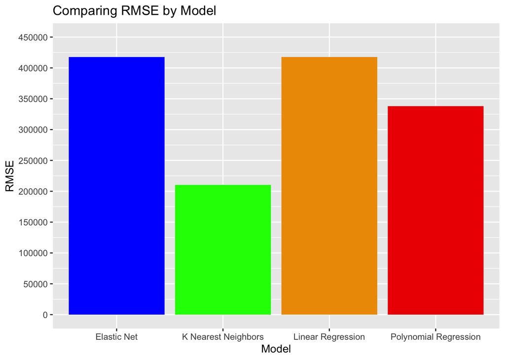

[figure not shown]

```r
# Creating a data frame of the model RMSE's so we can plot
all_models <- data.frame(Model = c("Linear Regression", "Polynomial Regression", "K Nearest Neighbors", "Elastic Net"),
                         RMSE = c(lm_rmse$mean, poly_rmse$mean, knn_rmse$mean, elastic_rmse$mean))

# Creating a barplot of the RMSE values
ggplot(all_models, aes(x = Model, y = RMSE)) +
  geom_bar(stat = "identity", aes(fill = Model)) +
  scale_fill_manual(values = c("blue1", "green1", "orange2", "red2")) +
  scale_y_continuous(limits = c(0, 450000), breaks = seq(0, 450000, 50000)) +
  theme(legend.position = "none") +
  labs(title = "Comparing RMSE by Model")
```

### Elastic Net Plot

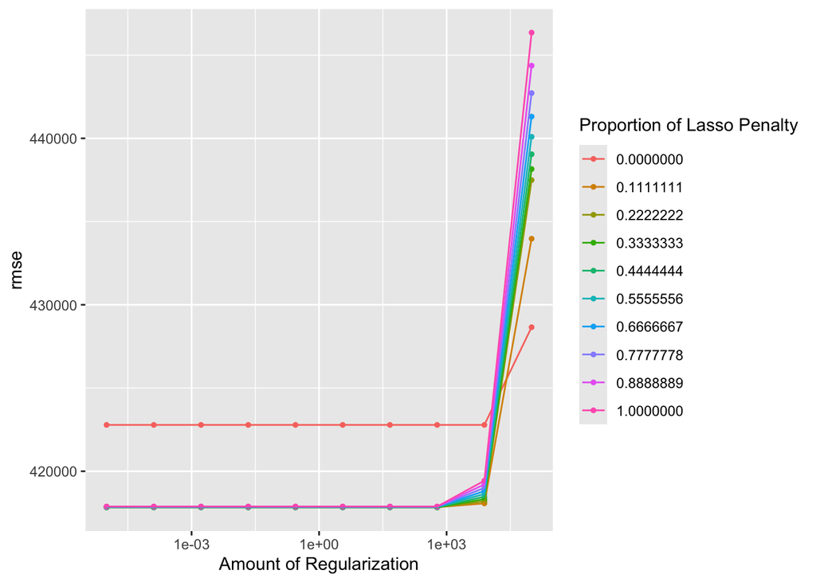

```r
autoplot(elastic_tuned, metric = 'rmse')
```

For the elastic net model, we tuned the parameters at 10 different levels. It seems as if 0.000 gives a higher rmse for regularization less than 1000, but after 1000, all of the other levels (except for 0.111) shoot way up.

### Polynomial Regression Plot

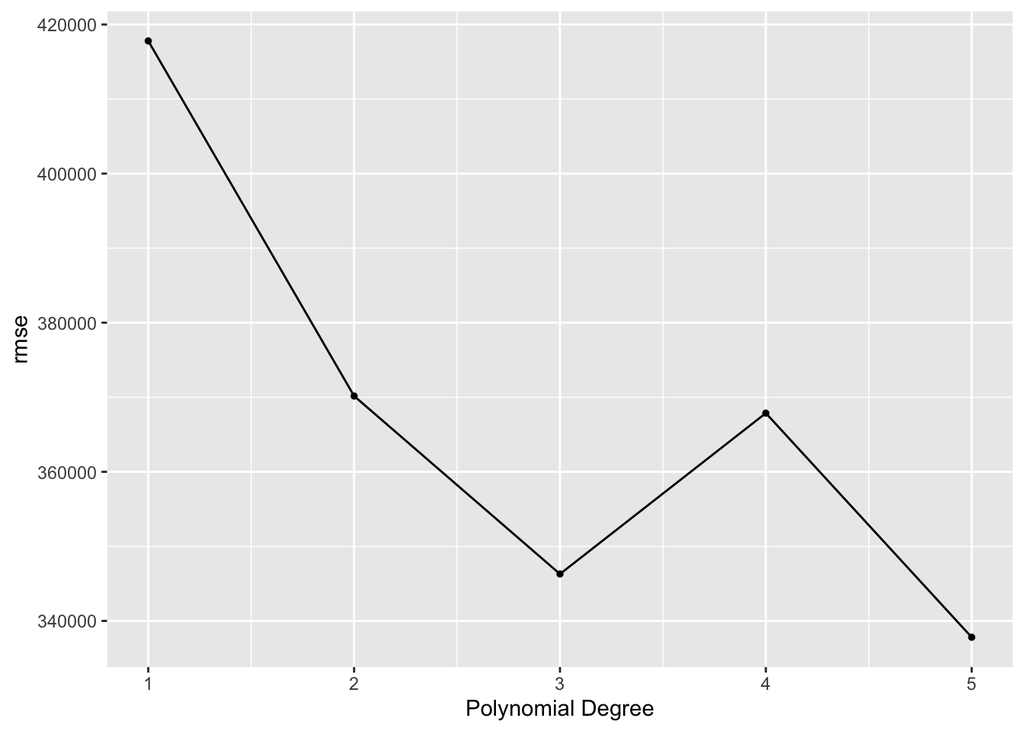

```r
autoplot(poly_tuned, metric = 'rmse')
```

### Results of the Best Model

```r
show_best(knn_tuned, metric = "rmse", n = 1)
```

```
## # A tibble: 1 × 7
##   neighbors .metric .estimator    mean     n std_err .config
##       <int> <chr>   <chr>        <dbl> <int>   <dbl> <chr>
## 1         8 rmse    standard   210574.    10  44090. Preprocessor1_Model3
```

### Fitting to Training data

Now we are going to feed our best model our training data. Yum! The model is going to train itself on the data, to prepare itself for whatever new data comes its way.

```r
# Fitting to the training data
best_knn_train <- select_best(knn_tuned, metric = 'rmse')
knn_final_workflow_train <- finalize_workflow(knn_workflow, best_knn_train)
knn_final_fit_train <- fit(knn_final_workflow_train, data = sportscar_train)



# Save
#write_rds(rf_final_fit_train, file = "data/rf_final/rf_final_train.rds")
#ridge_tuned <- read_rds(file = "data/tuned_models/ridge.rds")
write_rds(knn_final_fit_train, file = "~/Desktop/131 final Sam Arenson/knn_final/knn_final_train.rds")
```

### Testing the Model

Now that our model has eaten all of our tasty data, lets see how well it works on new data. The model has never seen this data before, so now we will be able to really see how well this model works to predict new values.

```r
knn_final_fit_train <- read_rds(file = "~/Desktop/131 final Sam Arenson/knn_final/knn_final_train.rds")

# Creating the predicted vs. actual value tibble
sportscar_tibble <- predict(knn_final_fit_train, new_data = sportscar_test %>% select(-Price))
sportscar_tibble <- bind_cols(sportscar_tibble, sportscar_test %>% select(Price))

# Save
write_rds(sportscar_tibble, file = "~/Desktop/131 final Sam Arenson/knn_final/final_model.rds")
```

```r
sportscar_tibble = read_rds(file = "~/Desktop/131 final Sam Arenson/knn_final/final_model.rds")

# Indicating the desired metric
sportscar_metric <- metric_set(rmse)

# Collecting the rmse of the model on the testing data
sportscar_tibble_metrics <- sportscar_metric(sportscar_tibble, truth = Price, estimate = .pred)
sportscar_tibble_metrics
```

```
## # A tibble: 1 × 3
##   .metric .estimator .estimate
##   <chr>   <chr>          <dbl>
## 1 rmse    standard     144598.
```

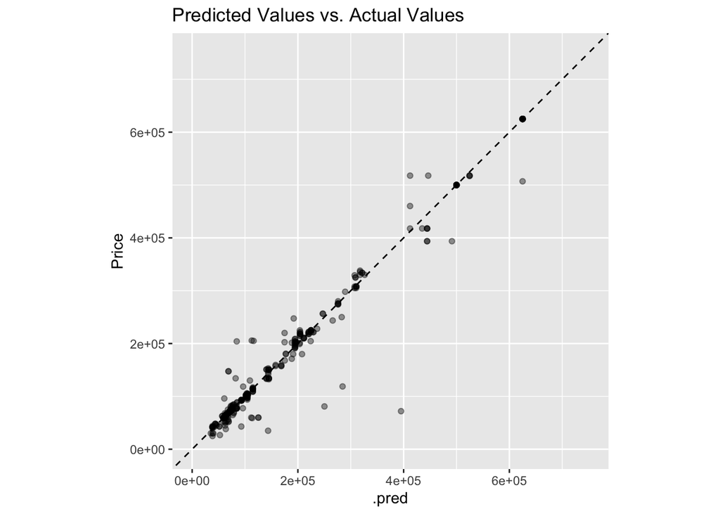

```r
sportscar_tibble %>%
  ggplot(aes(x = .pred, y = Price)) +
  geom_point(alpha = 0.4) +
  geom_abline(lty = 2) +
  theme_grey() +
  coord_obs_pred() +
  scale_x_continuous(limits = c(0, 750000)) +
  scale_y_continuous(limits = c(0, 750000)) +
  labs(title = "Predicted Values vs. Actual Values")
```

As we can see here, most of the dots are clinging to our line. This means that variance is low, aka our model did a great job predicting what price a car will be based on its horsepower, torque, engine size, and 0 to 60 time.

## Using Our Model

Now, we can use our model to predict the price of a vehicle from 2021-2022 based on it’s performance metrics. Lets go through some use cases.

First, lets say that I am a recently hired corporate employee with some extra cash laying around, and I’m looking to purchase an entry level sports car. I value horsepower over torque slightly, and although I want a sports car, I want it to be fuel efficient, not over the top with speed, and somewhat affordable. Based on my knowledge of automobiles, I would place this car at 3.5 liters, 350 horsepower, 280 lb-ft of torque, and a zero to sixty time of 4.7. Let’s see how much this car would cost, according to our model.

```r
engine_size123 <- 3.5
horsepower123 <- 350
torque123 <- 280
zero_to_sixty123 <- 4.7

input_data <- data.frame(
  EngineSize = engine_size123,
  Horsepower = horsepower123,
  Torque = torque123,
  ZeroToSixty = zero_to_sixty123
)


predicted_price <- predict(knn_final_fit_train, new_data = input_data)
print(paste("Predicted Price: $", round(predicted_price, 2)))
```

```
## [1] "Predicted Price: $ 43800.58"
```

Our vehicle would cost around $43,800. This is reasonable for a car at this performance level, and would most likely be a lower mid trim Audi, BMW, or Mercedes.

Let’s consider another use case.

Our new buyer is someone who has been saving up for the car of their dreams for quite some time. They want something fast, and they want a big engine to show off. Precise horsepower and torque metrics are not as relevant to them as the two metrics mentioned earlier. I would rate this car at 5.5 liters, 500 horsepower, 550 lb-ft of torque, and a 3.5 zero to sixty time.

```r
engine_size1234 <- 5.5
horsepower1234 <- 500
torque1234 <- 550
zero_to_sixty1234 <- 3.5

input_data1 <- data.frame(
  EngineSize = engine_size1234,
  Horsepower = horsepower1234,
  Torque = torque1234,
  ZeroToSixty = zero_to_sixty1234
)


predicted_price1 <- predict(knn_final_fit_train, new_data = input_data1)
print(paste("Predicted Price: $", round(predicted_price1, 2)))
```

```
## [1] "Predicted Price: $ 103373.27"
```

According to our model, the vehicle in question would cost around $103,000. This is a substantial step up from the first car we modeled. This car would most likely be a Porsche, or a high end BMW, Audi, or Mercedes. This automobile is far outside of the needs of any person, but well within the wants of many.

Now let’s propose our third car buyer.

```r
engine_size12345 <- 6.0
horsepower12345 <- 650
torque12345 <- 650
zero_to_sixty12345 <- 2.9

input_data12 <- data.frame(
  EngineSize = engine_size12345,
  Horsepower = horsepower12345,
  Torque = torque12345,
  ZeroToSixty = zero_to_sixty12345
)


predicted_price12 <- predict(knn_final_fit_train, new_data = input_data12)
print(paste("Predicted Price: $", round(predicted_price12, 2)))
```

```
## [1] "Predicted Price: $ 1257776.05"
```

Our model predicted that this car would cost about $1.25 million. This car would be a top of the line Ferrari, Lamborghini, Mclaren, Porsche, Buggati etc. This car would not only outperform everything on a race track, but also turn heads wherever it goes.

## Conclusion

After cleaning our data, analyzing the variables and how they interact with each other, building out model, training our model, testing our model, and running final diagnostics, we’ve finally built something that accurately predicts a cars price based on given values for horsepower, torque, 0 to 60 time, and engine size.

Now we have a model that can accurately predict the price of a vehicle made in 2021-2022. As seen above in the “Using Our Model” section, we can feed our model any number within the valid ranges for Horsepower, Torque, 0-60 time, and Engine size, and get a corresponding price.

## Limitations and Further Research

### Model Focus

The original aim of this study was to predict specific car models using performance metrics and price as predictors. However, this goal was not achieved due to the complexities associated with a categorical response involving over 1000 distinct car models. The challenges were mainly due to the high dimensionality and sparse distribution of data across numerous categories, which hindered effective learning and prediction accuracy in the model. This necessitated a reevaluation of the analytical approach.

### Lack of Significant Parameters in Dataset

While Price, Horsepower, 0-60 Time, and Engine Size are critical metrics, they represent only a fraction of the factors relevant in the car purchasing decision process. A more comprehensive dataset would ideally encompass additional parameters such as fuel efficiency, depreciation rates, availability or rarity, 60-130 time and cylinder count. Including these variables could significantly enhance the quantitative analysis of the multifaceted issue involved in selecting a car, providing a more holistic view of each vehicle’s attributes and their implications for buyers.

### Year

An additional crucial variable that was overlooked in the initial analysis is a comprehensive Year parameter. Although the dataset included year data, a closer examination revealed a predominance of vehicles from the years 2021 and 2022. This uniformity in model years enabled the analysis of car prices without the need for inflation adjustments. However, it also restricted our ability to investigate temporal variations in car prices and to explore how the age of a vehicle influences the purchasing decision. This limitation highlights the importance of a diverse temporal range in the dataset to fully understand pricing dynamics and consumer preferences over time.

### Moving forward

As mentioned earlier, many faults of this project were due to the data that was available. Car pricing data is hard to come by, as most of it is proprietary. However, I have seen independents conduct amazing high level analysis on car markets, so I know that the data is out there. My ongoing goal is to publish a program that can make the car buying process easier for everyone from the casual buyer to the enthusiast.

[figure not shown]